# Evidence1.1

Mariana Manzano Rico

2023-05-04

# **Introduction**

Humans are always looking for energy since it is crucial for every process around us, we can’t move, produce, build, or do anything without it, even our bodies need it to survive. That’s why different types of energy around the world exist, some older like petroleum or coal, and other new ones such as solar and wind energy. However, the consumption and production of these energies vary from country to country, it depends on other factors like investment, GDP, equipment, people, research, and obviously, the source to exist in the territory.

We also need to consider that even if energy is crucial for our lives, how people produce it (and use it) is not the best and has big consequences for our environment. Governments, organizations, and enterprises know it and that it must change, so they are looking for new ways and more friendly with the environment to produce energy and take it to every person in the easiest possible way.

In this case, we have the next problem situation: A company named AK Nacional del Monte, which provides energy for the retail industry needs to know whether it’s best to produce energy with new and renewable methods, to do it in the old way, or both, specifically for Brazil, Canada, Mexico, Haiti, and Venezuela. We, as data analysts, will consider different variables such as consumption of different energy types, production, intensity, GDP, CO2 emissions, and prices, which will be presented in this report.

# **Description of the variables**

```
## Rows: 55,440
## Columns: 11
## $ X                           <int> 0, 1, 2, 3, 4, 5, 6, 7, 8, 9, 10, 11, 12, …
## $ Country                     <chr> "World", "World", "World", "World", "World…
## $ Energy_type                 <chr> "all_energy_types", "coal", "natural_gas",…
## $ Year                        <int> 1980, 1980, 1980, 1980, 1980, 1980, 1980, …
## $ Energy_consumption          <dbl> 292.89979, 78.65613, 53.86522, 132.06402, …
## $ Energy_production           <dbl> 296.3372276, 80.1141943, 54.7610456, 133.1…
## $ GDP                         <dbl> 27771, 27771, 27771, 27771, 27771, 27771, …
## $ Population                  <dbl> 4298126.5, 4298126.5, 4298126.5, 4298126.5…
## $ Energy_intensity_per_capita <dbl> 68.15, 68.15, 68.15, 68.15, 68.15, 68.15, …
## $ Energy_intensity_by_GDP     <dbl> 10.5, 10.5, 10.5, 10.5, 10.5, 10.5, 0.0, 0…
## $ CO2_emission                <dbl> 4947, 1410, 1082, 2455, 0, 0, NA, NA, NA, …
```

```
## Rows: 17,432
## Columns: 122
## $ iso_code                                <chr> "AFG", "AFG", "AFG", "AFG", "A…
## $ country                                 <chr> "Afghanistan", "Afghanistan", …
## $ year                                    <int> 1900, 1901, 1902, 1903, 1904, …
## $ coal_prod_change_pct                    <dbl> NA, NA, NA, NA, NA, NA, NA, NA…
## $ coal_prod_change_twh                    <dbl> NA, 0, 0, 0, 0, 0, 0, 0, 0, 0,…
## $ gas_prod_change_pct                     <dbl> NA, NA, NA, NA, NA, NA, NA, NA…
## $ gas_prod_change_twh                     <dbl> NA, NA, NA, NA, NA, NA, NA, NA…
## $ oil_prod_change_pct                     <dbl> NA, NA, NA, NA, NA, NA, NA, NA…
## $ oil_prod_change_twh                     <dbl> NA, NA, NA, NA, NA, NA, NA, NA…
## $ energy_cons_change_pct                  <dbl> NA, NA, NA, NA, NA, NA, NA, NA…
## $ energy_cons_change_twh                  <dbl> NA, NA, NA, NA, NA, NA, NA, NA…
## $ biofuel_share_elec                      <dbl> NA, NA, NA, NA, NA, NA, NA, NA…
## $ biofuel_elec_per_capita                 <dbl> NA, NA, NA, NA, NA, NA, NA, NA…
```

[output cut: 109 more lines]

```
## Rows: 1,189,482
## Columns: 7
## $ country_or_area       <chr> "Austria", "Austria", "Belgium", "Belgium", "Bel…
## $ commodity_transaction <chr> "Additives and Oxygenates - Exports", "Additives…
## $ year                  <int> 1996, 1995, 2014, 2013, 2012, 2011, 2010, 2009, …
## $ unit                  <chr> "Metric tons,  thousand", "Metric tons,  thousan…
## $ quantity              <dbl> 5, 17, 0, 0, 35, 25, 22, 45, 1, 7, 9, 13, 39, 21…
## $ quantity_footnotes    <int> NA, NA, NA, NA, NA, NA, NA, NA, NA, NA, NA, NA, …
## $ category              <chr> "additives_and_oxygenates", "additives_and_oxyge…
```

However, these databases must be cleaned to make a good analysis of each variable. In this report we won’t give deep explanations of what we did because it is not the main purpose, however, it is necessary to understand what we did to clean the databases and the decisions we took based on what to understand the origin of the final databases.

We did the cleansing process for each database as it is seen in the following lines.

# **Cleansing Data Bases and Selecting Data**

## **Data Type**

First, we had to change the data type of some variables, from numeric to factor or from character to numeric, for each database. The next tables show the final data type for each column.

### **Energy**

```r
#Country<-fct
#Energy_type<-fct
#Year<-fct

energy<-energy_or%>%
  mutate(Country=as.factor(Country), Energy_type=as.factor(Energy_type), Year=as.factor(Year))

glimpse(energy)
```

```
## Rows: 55,440
## Columns: 11
## $ X                           <int> 0, 1, 2, 3, 4, 5, 6, 7, 8, 9, 10, 11, 12, …
## $ Country                     <fct> "World", "World", "World", "World", "World…
## $ Energy_type                 <fct> all_energy_types, coal, natural_gas, petro…
## $ Year                        <fct> 1980, 1980, 1980, 1980, 1980, 1980, 1980, …
## $ Energy_consumption          <dbl> 292.89979, 78.65613, 53.86522, 132.06402, …
## $ Energy_production           <dbl> 296.3372276, 80.1141943, 54.7610456, 133.1…
## $ GDP                         <dbl> 27771, 27771, 27771, 27771, 27771, 27771, …
## $ Population                  <dbl> 4298126.5, 4298126.5, 4298126.5, 4298126.5…
## $ Energy_intensity_per_capita <dbl> 68.15, 68.15, 68.15, 68.15, 68.15, 68.15, …
## $ Energy_intensity_by_GDP     <dbl> 10.5, 10.5, 10.5, 10.5, 10.5, 10.5, 0.0, 0…
## $ CO2_emission                <dbl> 4947, 1410, 1082, 2455, 0, 0, NA, NA, NA, …
```

### **Consumption**

```r
## Select the necesary
#iso_code:year, oil_consumption, other_renewable_consumption, renewable_consumption, wind_consumption, solar_consumption.

#iso_code<-fct
#country<-fct
#year<-fct

consumption<-consumption_or%>%
  select(iso_code:year, oil_consumption, other_renewable_consumption, renewables_consumption, wind_consumption, solar_consumption)%>%
  mutate(iso_code=as.factor(iso_code), country=as.factor(country), year=as.factor(year))

glimpse(consumption)
```

```
## Rows: 17,432
## Columns: 8
## $ iso_code                    <fct> AFG, AFG, AFG, AFG, AFG, AFG, AFG, AFG, AF…
## $ country                     <fct> Afghanistan, Afghanistan, Afghanistan, Afg…
## $ year                        <fct> 1900, 1901, 1902, 1903, 1904, 1905, 1906, …
## $ oil_consumption             <dbl> NA, NA, NA, NA, NA, NA, NA, NA, NA, NA, NA…
## $ other_renewable_consumption <dbl> NA, NA, NA, NA, NA, NA, NA, NA, NA, NA, NA…
## $ renewables_consumption      <dbl> NA, NA, NA, NA, NA, NA, NA, NA, NA, NA, NA…
## $ wind_consumption            <dbl> NA, NA, NA, NA, NA, NA, NA, NA, NA, NA, NA…
## $ solar_consumption           <dbl> NA, NA, NA, NA, NA, NA, NA, NA, NA, NA, NA…
```

### **Statistics**

```r
#Unselect quantity_footnotes

#country_or_area<-fct
#commodity_transaction<-fct
#year<-fct
#unit<-fct
#category<-fct

statistics<-statistics_or%>%
  select(-quantity_footnotes)%>%
  mutate(country_or_area=as.factor(country_or_area), commodity_transaction=as.factor(commodity_transaction), year=as.factor(year), unit=as.factor(unit), category=as.factor(category))

glimpse(statistics)
```

```
## Rows: 1,189,482
## Columns: 6
## $ country_or_area       <fct> "Austria", "Austria", "Belgium", "Belgium", "Bel…
## $ commodity_transaction <fct> "Additives and Oxygenates - Exports", "Additives…
## $ year                  <fct> 1996, 1995, 2014, 2013, 2012, 2011, 2010, 2009, …
## $ unit                  <fct> "Metric tons,  thousand", "Metric tons,  thousan…
## $ quantity              <dbl> 5, 17, 0, 0, 35, 25, 22, 45, 1, 7, 9, 13, 39, 21…
## $ category              <fct> additives_and_oxygenates, additives_and_oxygenat…
```

## **Filter Data**

At this point, we decided to select only the data crucial for our analysis, this means that we only select the countries that we will study in this report (Brazil, Canada, Venezuela, Mexico, and Haiti).

```r
#Mexico, Brazil, Canada, Venezuela, and Haiti.
#Energy in the old fashion way, shift to different production methods
```

### **Energy**

```r
energy<-energy%>%
  filter(Country %in% c("Mexico", "Brazil", "Canada", "Venezuela", "Haiti"))

summary(energy$Energy_type)
```

```
##          all_energy_types                      coal               natural_gas
##                       200                       200                       200
##                   nuclear petroleum_n_other_liquids        renewables_n_other
##                       200                       200                       200
```

### **Consumption**

```r
consumption<-consumption%>%
  filter(country %in% c("Mexico", "Brazil", "Canada", "Venezuela", "Haiti"))
```

### **Statistics**

```r
statistics<-statistics%>%
  filter(country_or_area %in% c("Mexico", "Brazil", "Canada", "Venezuela", "Haiti"), str_detect(category, "coal") |  str_detect(category, "natural_gas") | str_detect(category, "nuclear") | str_detect(category, "petroleum") | str_detect(category, "renewables") | str_detect(category, "oil") | str_detect(category, "wind") | str_detect(category, "solar"), str_detect(commodity_transaction, "final consumption"), !str_detect(commodity_transaction, "Other bituminous coal"), !str_detect(commodity_transaction, "Coking coal"), !str_detect(commodity_transaction, "Hard coal"), !str_detect(commodity_transaction, "White spirit and special boiling point industrial spirits"))

group_by(statistics, category)
```

```
## # A tibble: 189 × 6
## # Groups:   category [4]
##    country_or_area commodity_transaction             year  unit  quant…¹ categ…²
##    <fct>           <fct>                             <fct> <fct>   <dbl> <fct>
##  1 Mexico          Brown coal briquettes - final co… 2014  Metr…       3 brown_…
##  2 Mexico          Brown coal briquettes - final co… 2013  Metr…       4 brown_…
##  3 Mexico          Brown coal briquettes - final co… 2012  Metr…       4 brown_…
##  4 Canada          Brown coal - final consumption    2014  Metr…    2044 brown_…
##  5 Canada          Brown coal - final consumption    2013  Metr…    1128 brown_…
##  6 Canada          Brown coal - final consumption    2012  Metr…    1002 brown_…
##  7 Canada          Brown coal - final consumption    2011  Metr…     956 brown_…
##  8 Canada          Brown coal - final consumption    2010  Metr…    1761 brown_…
##  9 Canada          Brown coal - final consumption    2009  Metr…    1923 brown_…
## 10 Canada          Brown coal - final consumption    2008  Metr…    2286 brown_…
## # … with 179 more rows, and abbreviated variable names ¹quantity, ²category
```

```r
#Use "contains" in category
  #All energy
  #coal
  #natural_gas
  #nuclear
  #petroleum
  #renewables
  #oil
  #wind
  #solar
```

The final databases are the following ones:

```r
glimpse(energy)
```

```
## Rows: 1,200
## Columns: 11
## $ X                           <int> 156, 157, 158, 159, 160, 161, 216, 217, 21…
## $ Country                     <fct> "Brazil", "Brazil", "Brazil", "Brazil", "B…
## $ Energy_type                 <fct> all_energy_types, coal, natural_gas, petro…
## $ Year                        <fct> 1980, 1980, 1980, 1980, 1980, 1980, 1980, …
## $ Energy_consumption          <dbl> 3.89638, 0.21372, 0.05662, 2.25691, NA, 1.…
## $ Energy_production           <dbl> 1.98066, 0.08352, 0.05662, 0.40301, NA, 1.…
## $ GDP                         <dbl> 1305, 1305, 1305, 1305, 1305, 1305, 694, 6…
## $ Population                  <dbl> 121051, 121051, 121051, 121051, 121051, 12…
## $ Energy_intensity_per_capita <dbl> 32.19, 32.19, 32.19, 32.19, 32.19, 32.19, …
## $ Energy_intensity_by_GDP     <dbl> 2.99, 2.99, 2.99, 2.99, 2.99, 2.99, 13.76,…
## $ CO2_emission                <dbl> NA, NA, NA, NA, 0, 0, NA, NA, NA, NA, 0, 0…
```

```r
glimpse(consumption)
```

```
## Rows: 523
## Columns: 8
## $ iso_code                    <fct> BRA, BRA, BRA, BRA, BRA, BRA, BRA, BRA, BR…
## $ country                     <fct> Brazil, Brazil, Brazil, Brazil, Brazil, Br…
## $ year                        <fct> 1900, 1901, 1902, 1903, 1904, 1905, 1906, …
## $ oil_consumption             <dbl> NA, NA, NA, NA, NA, NA, NA, NA, NA, NA, NA…
## $ other_renewable_consumption <dbl> NA, NA, NA, NA, NA, NA, NA, NA, NA, NA, NA…
## $ renewables_consumption      <dbl> NA, NA, NA, NA, NA, NA, NA, NA, NA, NA, NA…
## $ wind_consumption            <dbl> NA, NA, NA, NA, NA, NA, NA, NA, NA, NA, NA…
## $ solar_consumption           <dbl> NA, NA, NA, NA, NA, NA, NA, NA, NA, NA, NA…
```

```r
glimpse(statistics)
```

```
## Rows: 189
## Columns: 6
## $ country_or_area       <fct> "Mexico", "Mexico", "Mexico", "Canada", "Canada"…
## $ commodity_transaction <fct> "Brown coal briquettes - final consumption", "Br…
## $ year                  <fct> 2014, 2013, 2012, 2014, 2013, 2012, 2011, 2010, …
## $ unit                  <fct> "Metric tons,  thousand", "Metric tons,  thousan…
## $ quantity              <dbl> 3, 4, 4, 2044, 1128, 1002, 956, 1761, 1923, 2286…
## $ category              <fct> brown_coal_briquettes, brown_coal_briquettes, br…
```

## **Uniqueness Restrictions**

We also needed to know if there were complete or partial duplications of registries, but we found there are not any duplicates, so we didn’t have to do anything more in this step.

### Complete duplicates

```r
sum(duplicated(energy))
```

```
## [1] 0
```

```r
sum(duplicated(consumption))
```

```
## [1] 0
```

```r
sum(duplicated(statistics))
```

```
## [1] 0
```

### **Energy**

```r
dup_x <- energy %>%
  count(X) %>%
  filter(n > 1)
dup_x
```

```
## [1] X n
## <0 rows> (or 0-length row.names)
```

## **Category review**

The category review means every category to be correctly presented in the database (for example, having *natural_gas* and *Natural_gas* is not the same in R). We checked each category of each database in order to confirm we don’t have to do any category collapse.

### **Energy**

```r
#Country
#Energy_type

sumcounen <-energy%>%
  count(Country)

sumcounen
```

```
##     Country   n
## 1    Brazil 240
## 2    Canada 240
## 3     Haiti 240
## 4    Mexico 240
## 5 Venezuela 240
```

```r
sumeneren<-energy%>%
  count(Energy_type)

sumeneren
```

```
##                 Energy_type   n
## 1          all_energy_types 200
## 2                      coal 200
## 3               natural_gas 200
## 4                   nuclear 200
## 5 petroleum_n_other_liquids 200
## 6        renewables_n_other 200
```

### **Consumption**

```r
#country
#iso_code

sumcouncon <-consumption%>%
  count(country)

sumcouncon
```

```
##     country   n
## 1    Brazil 121
## 2    Canada 121
## 3     Haiti  40
## 4    Mexico 121
## 5 Venezuela 120
```

```r
isocon <-consumption%>%
  count(iso_code)

isocon
```

```
##   iso_code   n
## 1      BRA 121
## 2      CAN 121
## 3      HTI  40
## 4      MEX 121
## 5      VEN 120
```

### **Statistics**

```r
#country_or_area
#commodity_transaction
#year
#unit
#category

counst <-statistics%>%
  count(country_or_area)

counst
```

```
##   country_or_area  n
## 1          Brazil 50
## 2          Canada 75
## 3          Mexico 64
```

```r
comst <-statistics%>%
  count(commodity_transaction)

comst
```

```
##                             commodity_transaction  n
## 1                  Brown coal - final consumption 39
## 2       Brown coal briquettes - final consumption  3
## 3 Natural gas (including LNG) - final consumption 75
## 4              Petroleum coke - final consumption 72
```

```r
yeast <-statistics%>%
  count(year)

yeast
```

```
##    year n
## 1  1990 6
## 2  1991 6
## 3  1992 6
## 4  1993 7
## 5  1994 7
## 6  1995 7
## 7  1996 7
## 8  1997 7
## 9  1998 7
## 10 1999 7
## 11 2000 7
## 12 2001 8
## 13 2002 8
## 14 2003 8
## 15 2004 8
## 16 2005 8
## 17 2006 8
## 18 2007 8
## 19 2008 8
## 20 2009 8
## 21 2010 8
## 22 2011 8
## 23 2012 9
## 24 2013 9
## 25 2014 9
```

```r
unist <-statistics%>%
  count(unit)

unist
```

```
##                     unit   n
## 1 Metric tons,  thousand 114
## 2             Terajoules  75
```

```r
catst <-statistics%>%
  count(category)

catst
```

```
##                    category  n
## 1                brown_coal 39
## 2     brown_coal_briquettes  3
## 3 natural_gas_including_lng 75
## 4            petroleum_coke 72
```

```r
#commodity_transaction
   # brown coal
   #others white spirit...
```

We found we don’t have any problems related to categories.

## **Missing Data**

It is necessary to look for the missing data and that is what we did in this section for each one of the databases:

### **Energy**

```r
n_miss(energy)
```

```
## [1] 252
```

```r
prop_miss(energy)
```

```
## [1] 0.0191
```

### **Consumption**

```r
n_miss(consumption)
```

```
## [1] 1515
```

```r
prop_miss(consumption)
```

```
## [1] 0.362
```

### **Statistics**

```r
n_miss(statistics)
```

```
## [1] 0
```

```r
prop_miss(statistics)
```

```
## [1] 0
```

Finally, in statistics, we don’t have any missing data.

### **Energy**

```r
miss_var_summary(energy)
```

```
## # A tibble: 11 × 3
##    variable                    n_miss pct_miss
##    <chr>                        <int>    <dbl>
##  1 Energy_consumption              92     7.67
##  2 Energy_production               92     7.67
##  3 GDP                             48     4
##  4 CO2_emission                    20     1.67
##  5 X                                0     0
##  6 Country                          0     0
##  7 Energy_type                      0     0
##  8 Year                             0     0
##  9 Population                       0     0
## 10 Energy_intensity_per_capita      0     0
## 11 Energy_intensity_by_GDP          0     0
```

```r
miss_case_summary(energy)
```

```
## # A tibble: 1,200 × 3
##     case n_miss pct_miss
##    <int>  <int>    <dbl>
##  1    17      3     27.3
##  2    47      3     27.3
##  3    77      3     27.3
##  4   107      3     27.3
##  5   137      3     27.3
##  6   167      3     27.3
##  7   197      3     27.3
##  8   227      3     27.3
##  9     5      2     18.2
## 10    13      2     18.2
## # … with 1,190 more rows
```

```r
miss_var_table(energy)
```

```
## # A tibble: 4 × 3
##   n_miss_in_var n_vars pct_vars
##           <int>  <int>    <dbl>
## 1             0      7    63.6
## 2            20      1     9.09
## 3            48      1     9.09
## 4            92      2    18.2
```

```r
miss_case_table(energy)
```

```
## # A tibble: 4 × 3
##   n_miss_in_case n_cases pct_cases
##            <int>   <int>     <dbl>
## 1              0    1052    87.7
## 2              1      52     4.33
## 3              2      88     7.33
## 4              3       8     0.667
```

```r
energy %>% group_by(Year) %>% miss_var_summary()
```

```
## # A tibble: 400 × 4
## # Groups:   Year [40]
##    Year  variable                    n_miss pct_miss
##    <fct> <chr>                        <int>    <dbl>
##  1 1980  CO2_emission                    20     66.7
##  2 1980  GDP                              6     20
##  3 1980  Energy_consumption               4     13.3
##  4 1980  Energy_production                4     13.3
##  5 1980  X                                0      0
##  6 1980  Country                          0      0
##  7 1980  Energy_type                      0      0
##  8 1980  Population                       0      0
##  9 1980  Energy_intensity_per_capita      0      0
## 10 1980  Energy_intensity_by_GDP          0      0
## # … with 390 more rows
```

```r
energy %>% group_by(Year) %>% miss_case_summary()
```

```
## # A tibble: 1,200 × 4
## # Groups:   Year [40]
##    Year   case n_miss pct_miss
##    <fct> <int>  <int>    <dbl>
##  1 1980     17      3       30
##  2 1980      5      2       20
##  3 1980     13      2       20
##  4 1980     14      2       20
##  5 1980     15      2       20
##  6 1980     16      2       20
##  7 1980     23      2       20
##  8 1980     29      2       20
##  9 1980      1      1       10
## 10 1980      2      1       10
## # … with 1,190 more rows
```

First, in Energy we see that the Variable with the most NAs is `Energy_consumption` and `Energy_production`, in each one, 7.67% is missing data. On the other hand, the most NAs a registry has in this dataset are three, as we can see in the second table. In the third one, we can see that 63.64% is not missing data. Finally, in the last two tables, we can see that 1980 is the year with the most NAs, especially in the variable `CO2_emission`.

### **Consumption**

```r
miss_var_summary(consumption)
```

```
## # A tibble: 8 × 3
##   variable                    n_miss pct_miss
##   <chr>                        <int>    <dbl>
## 1 oil_consumption                303     57.9
## 2 other_renewable_consumption    303     57.9
## 3 renewables_consumption         303     57.9
## 4 wind_consumption               303     57.9
## 5 solar_consumption              303     57.9
## 6 iso_code                         0      0
## 7 country                          0      0
## 8 year                             0      0
```

```r
miss_case_summary(consumption)
```

```
## # A tibble: 523 × 3
##     case n_miss pct_miss
##    <int>  <int>    <dbl>
##  1     1      5     62.5
##  2     2      5     62.5
##  3     3      5     62.5
##  4     4      5     62.5
##  5     5      5     62.5
##  6     6      5     62.5
##  7     7      5     62.5
##  8     8      5     62.5
##  9     9      5     62.5
## 10    10      5     62.5
## # … with 513 more rows
```

```r
miss_var_table(consumption)
```

```
## # A tibble: 2 × 3
##   n_miss_in_var n_vars pct_vars
##           <int>  <int>    <dbl>
## 1             0      3     37.5
## 2           303      5     62.5
```

```r
miss_case_table(consumption)
```

```
## # A tibble: 2 × 3
##   n_miss_in_case n_cases pct_cases
##            <int>   <int>     <dbl>
## 1              0     220      42.1
## 2              5     303      57.9
```

```r
consumption %>% group_by(year) %>% miss_var_summary()
```

```
## # A tibble: 847 × 4
## # Groups:   year [121]
##    year  variable                    n_miss pct_miss
##    <fct> <chr>                        <int>    <dbl>
##  1 1900  oil_consumption                  4      100
##  2 1900  other_renewable_consumption      4      100
##  3 1900  renewables_consumption           4      100
##  4 1900  wind_consumption                 4      100
##  5 1900  solar_consumption                4      100
##  6 1900  iso_code                         0        0
##  7 1900  country                          0        0
##  8 1901  oil_consumption                  4      100
##  9 1901  other_renewable_consumption      4      100
## 10 1901  renewables_consumption           4      100
## # … with 837 more rows
```

```r
consumption %>% group_by(year) %>% miss_case_summary()
```

```
## # A tibble: 523 × 4
## # Groups:   year [121]
##    year   case n_miss pct_miss
##    <fct> <int>  <int>    <dbl>
##  1 1900      1      5     71.4
##  2 1900      2      5     71.4
##  3 1900      3      5     71.4
##  4 1900      4      5     71.4
##  5 1901      1      5     71.4
##  6 1901      2      5     71.4
##  7 1901      3      5     71.4
##  8 1901      4      5     71.4
##  9 1902      1      5     71.4
## 10 1902      2      5     71.4
## # … with 513 more rows
```

We didn’t do the analysis of Statistics because as we saw before, it doesn’t have missing data.

### Display of Missing Data

The proportions of missing data in each variable can be seen in the next graphs:

### **Energy**

For energy, it is shown like this:

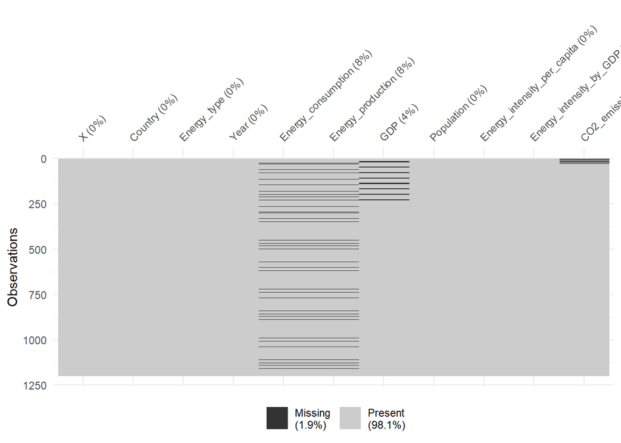

```r
vis_miss(energy)
```

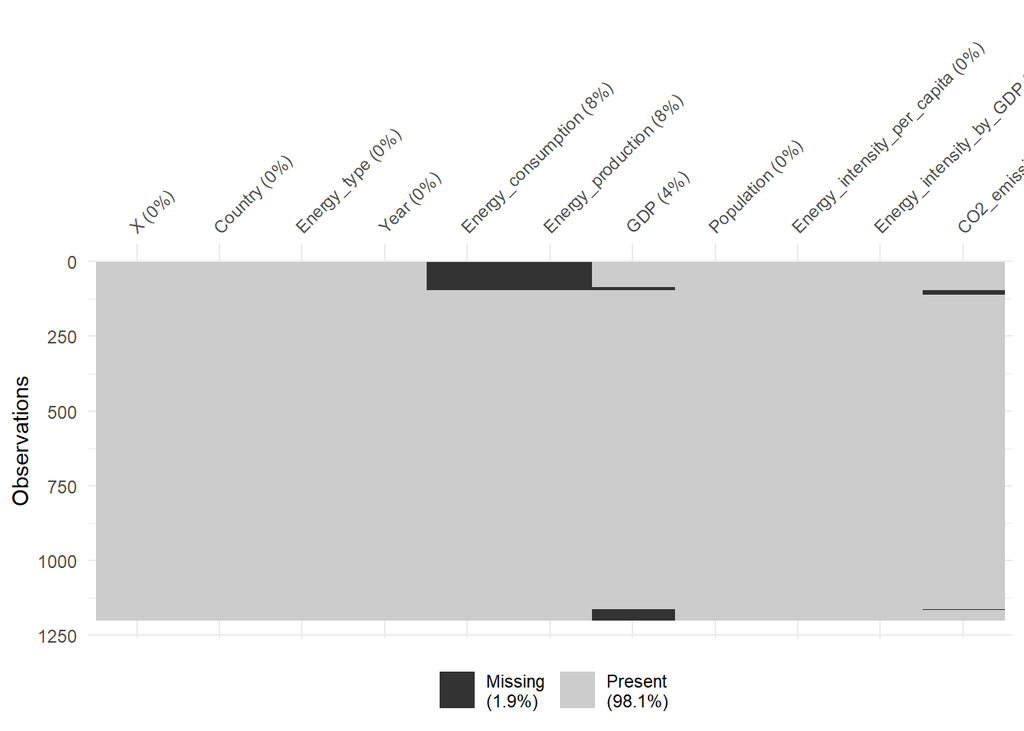

```r
vis_miss(energy, cluster = TRUE)
```

### **Consumption**

For Consumption it is seen like this:

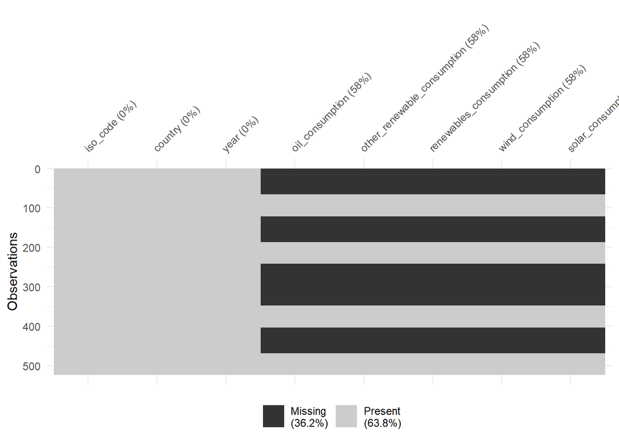

```r
vis_miss(consumption)
```

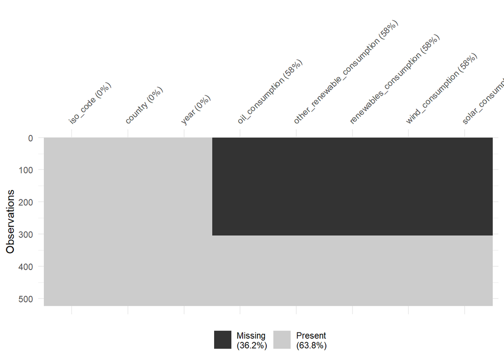

```r
vis_miss(consumption, cluster = TRUE)
```

Another way to see the missing data is per variable in energy and consumption as it is shown in the next images:

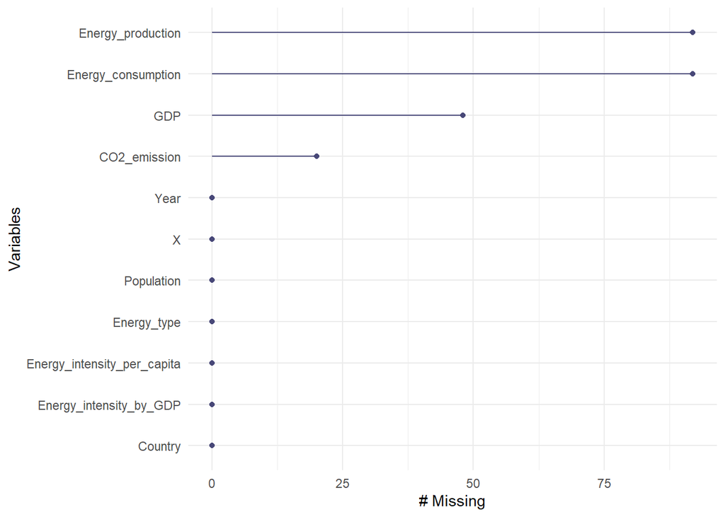

```r
gg_miss_var(energy)
```

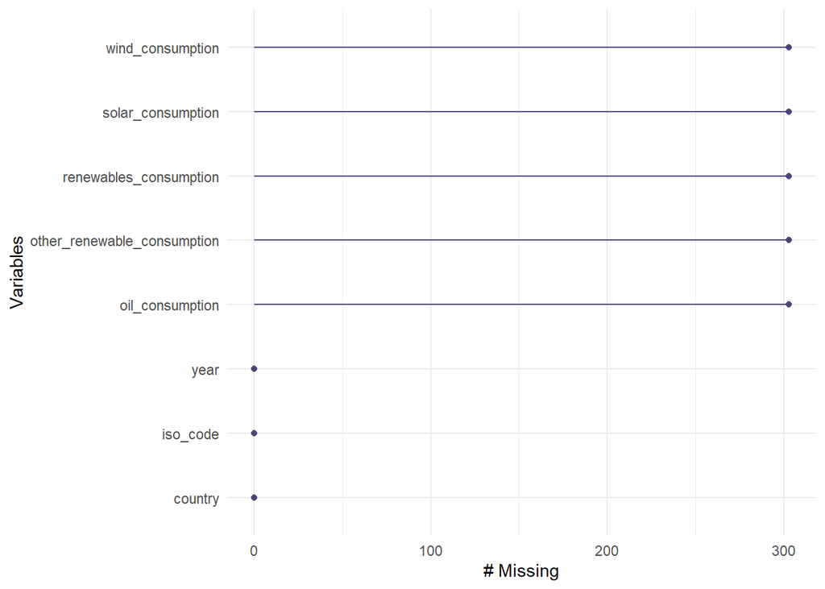

```r
gg_miss_var(consumption)
```

We confirm what we saw on the tables, that `Energy_production` and `Energy_consumption` are the variables in energy with the most missing data while in consumption are `wind_consumption`, `solar_consumption`, `renewables_consumption`, `other_renewable_consumption` and `oil_consumption`.

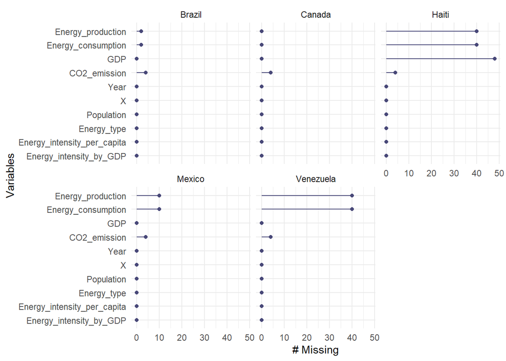

```r
gg_miss_var(energy, facet = Country)
```

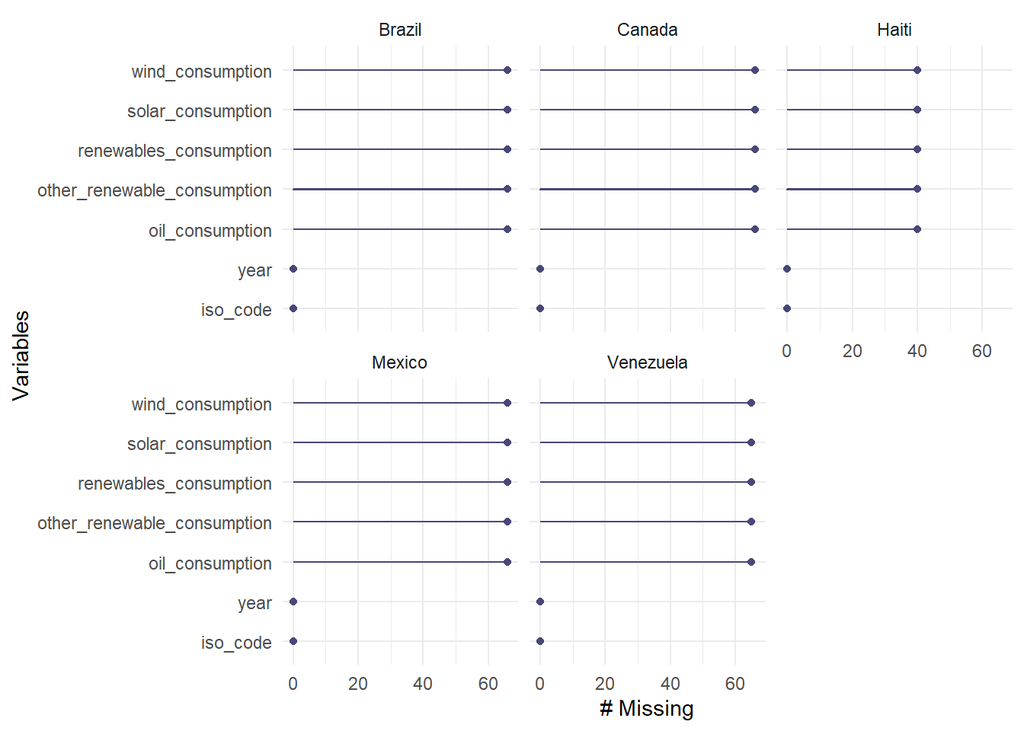

```r
gg_miss_var(consumption, facet = country)
```

This also can be seen by country in each of the datasets. In Energy, we see that Haiti, Venezuela, and Mexico are the ones with the most NAs while in Consumption, Haiti is the one with fewer NAs.

Talking about cases and not variables, the proportion of missing data can be seen like this in each of the databases:

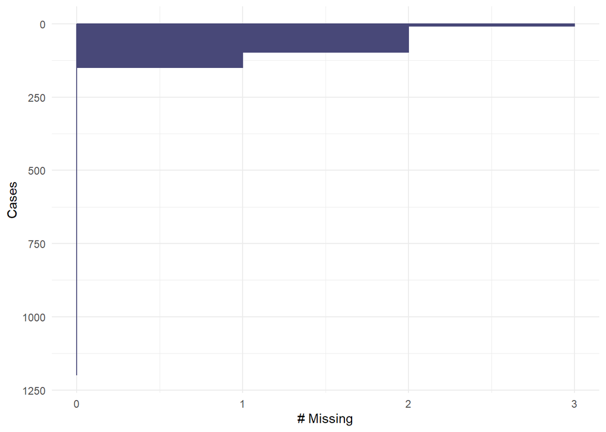

```r
gg_miss_case(energy)
```

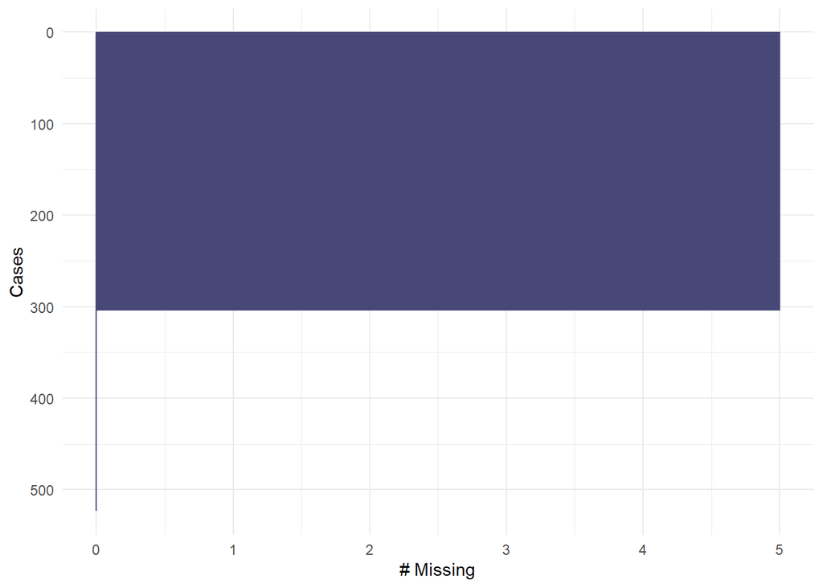

```r
gg_miss_case(consumption)
```

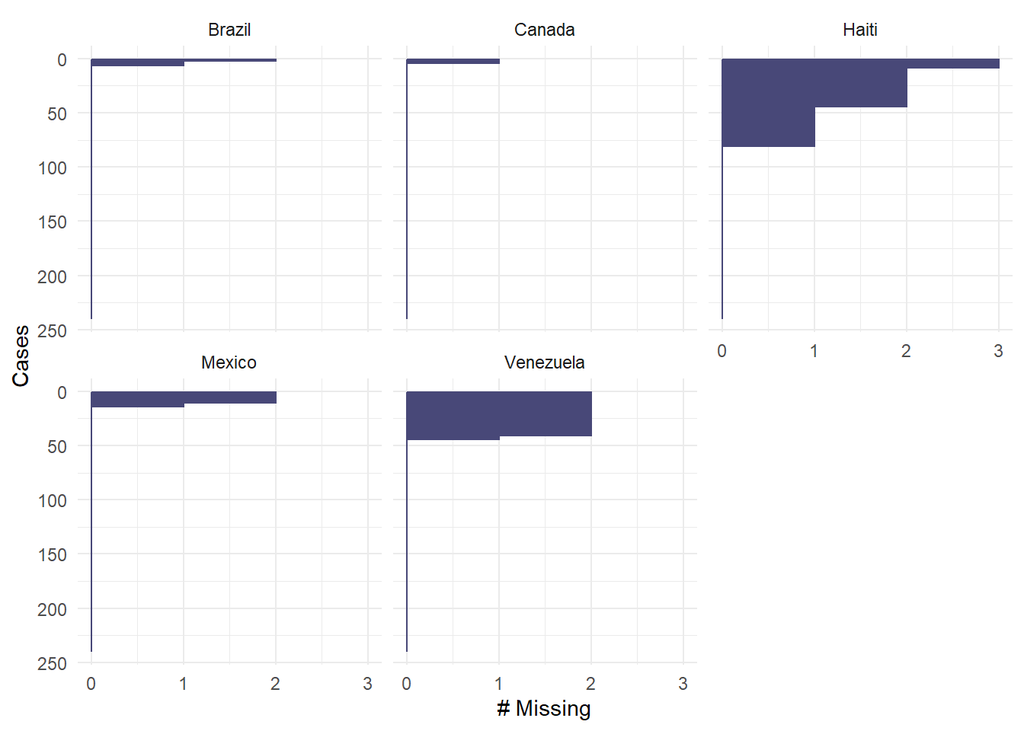

```r
gg_miss_case(energy, facet = Country)
```

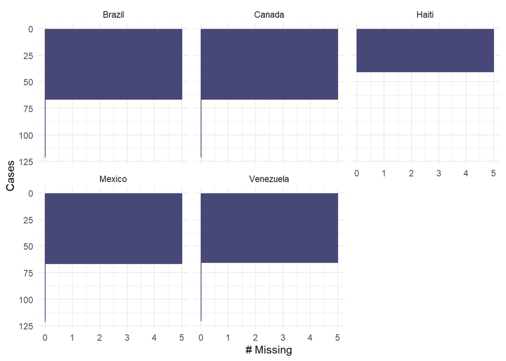

```r
gg_miss_case(consumption, facet = country)
```

Again, we can see it by country for each data set. In Energy, Haiti, Mexico, and Venezuela are the ones with the most, and in Consumption, Haiti is the one with the fewer.

### Missing Patterns

On the other hand, some patterns between NAs can be seen in the following graphs. For energy, some NAs in `Energy_production` also have in `Energy_consumption` and some others in `GDP`, some NAs in `GDP` also have it in `CO2_emissions` and finally there are some NAs in `GDP` and `CO2_emissions` that are not related to any other variable.

This is not the same case in Consumption, where the registries that have an NA in any column have as well in the others.

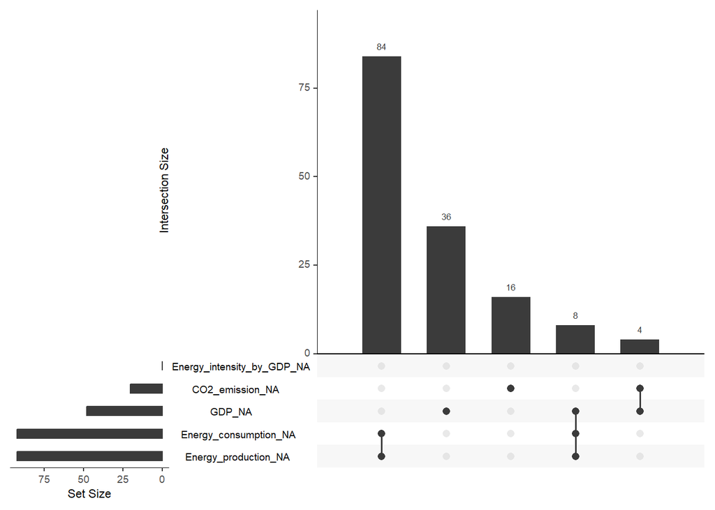

```r
gg_miss_upset(energy)
```

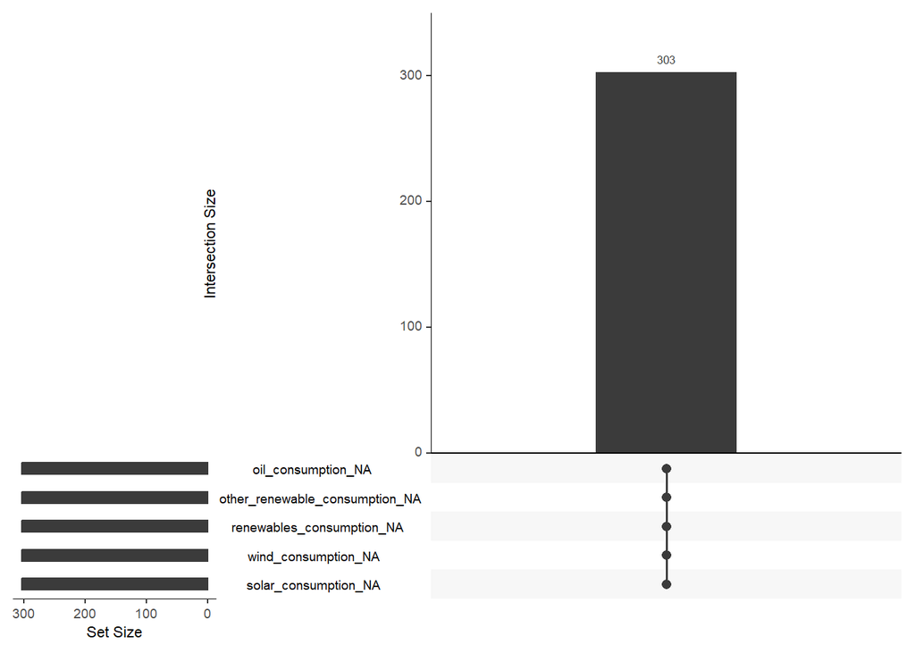

```r
gg_miss_upset(consumption)
```

### Missing Dependence

It is also important to comprehend the relation between variables with NAs and it is what we did in this section. At first, we must create new columns with nabularies, which tell us if the data of each variable is missing or not missing.

### **Energy**

```r
#Nabulares

bind_shadow(energy, only_miss = TRUE)
```

```
## # A tibble: 1,200 × 15
##        X Country Energy_type Year  Energ…¹ Energ…²   GDP Popul…³ Energ…⁴ Energ…⁵
##    <int> <fct>   <fct>       <fct>   <dbl>   <dbl> <dbl>   <dbl>   <dbl>   <dbl>
##  1   156 Brazil  all_energy… 1980   3.90    1.98   1305. 121051.    32.2    2.99
##  2   157 Brazil  coal        1980   0.214   0.0835 1305. 121051.    32.2    2.99
##  3   158 Brazil  natural_gas 1980   0.0566  0.0566 1305. 121051.    32.2    2.99
##  4   159 Brazil  petroleum_… 1980   2.26    0.403  1305. 121051.    32.2    2.99
##  5   160 Brazil  nuclear     1980  NA      NA      1305. 121051.    32.2    2.99
##  6   161 Brazil  renewables… 1980   1.37    1.44   1305. 121051.    32.2    2.99
##  7   216 Canada  all_energy… 1980   9.55   10.2     694.  24516.   390.    13.8
##  8   217 Canada  coal        1980   0.786   0.777   694.  24516.   390.    13.8
##  9   218 Canada  natural_gas 1980   1.92    2.81    694.  24516.   390.    13.8
## 10   219 Canada  petroleum_… 1980   3.90    3.53    694.  24516.   390.    13.8
## # … with 1,190 more rows, 5 more variables: CO2_emission <dbl>,
## #   Energy_consumption_NA <fct>, Energy_production_NA <fct>, GDP_NA <fct>,
## #   CO2_emission_NA <fct>, and abbreviated variable names ¹Energy_consumption,
## #   ²Energy_production, ³Population, ⁴Energy_intensity_per_capita,
## #   ⁵Energy_intensity_by_GDP
```

### **Consumption**

```r
#Nabulares

bind_shadow(consumption, only_miss = TRUE)
```

```
## # A tibble: 523 × 13
##    iso_c…¹ country year  oil_c…² other…³ renew…⁴ wind_…⁵ solar…⁶ oil_c…⁷ other…⁸
##    <fct>   <fct>   <fct>   <dbl>   <dbl>   <dbl>   <dbl>   <dbl> <fct>   <fct>
##  1 BRA     Brazil  1900       NA      NA      NA      NA      NA NA      NA
##  2 BRA     Brazil  1901       NA      NA      NA      NA      NA NA      NA
##  3 BRA     Brazil  1902       NA      NA      NA      NA      NA NA      NA
##  4 BRA     Brazil  1903       NA      NA      NA      NA      NA NA      NA
##  5 BRA     Brazil  1904       NA      NA      NA      NA      NA NA      NA
##  6 BRA     Brazil  1905       NA      NA      NA      NA      NA NA      NA
##  7 BRA     Brazil  1906       NA      NA      NA      NA      NA NA      NA
##  8 BRA     Brazil  1907       NA      NA      NA      NA      NA NA      NA
##  9 BRA     Brazil  1908       NA      NA      NA      NA      NA NA      NA
## 10 BRA     Brazil  1909       NA      NA      NA      NA      NA NA      NA
## # … with 513 more rows, 3 more variables: renewables_consumption_NA <fct>,
## #   wind_consumption_NA <fct>, solar_consumption_NA <fct>, and abbreviated
## #   variable names ¹iso_code, ²oil_consumption, ³other_renewable_consumption,
## #   ⁴renewables_consumption, ⁵wind_consumption, ⁶solar_consumption,
## #   ⁷oil_consumption_NA, ⁸other_renewable_consumption_NA
```

### Variation in one variable according to shortages in another variable

Then we create graphs to visualize these relations, we found that the ones that are related to one another are:

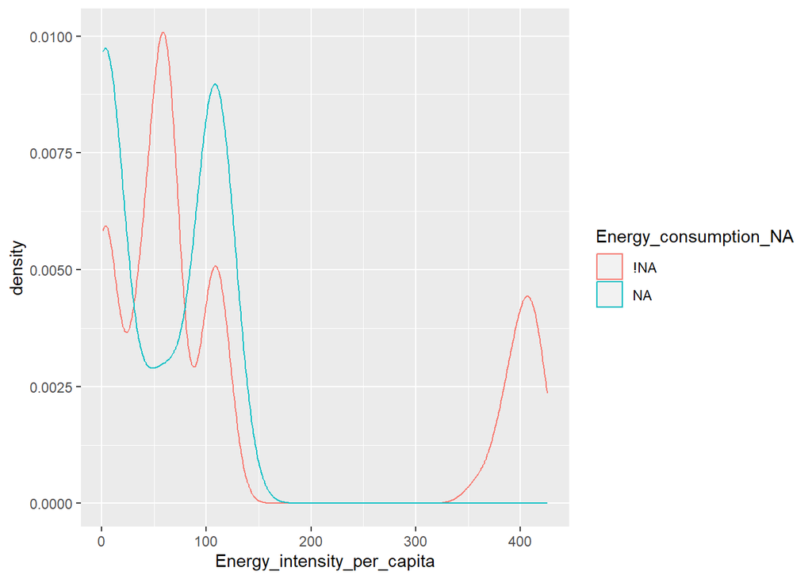

```r
#Missing Data
  #Energy_consumption
  #Energy_production
  #GDP
  #CO2_emission

#Possible Variation
  #Energy_intensity_per_capita
  #Energy_intensity_by_GDP

energy%>%
  bind_shadow()%>%
  ggplot(aes(x = Energy_intensity_per_capita, color = Energy_consumption_NA))+
  geom_density()
```

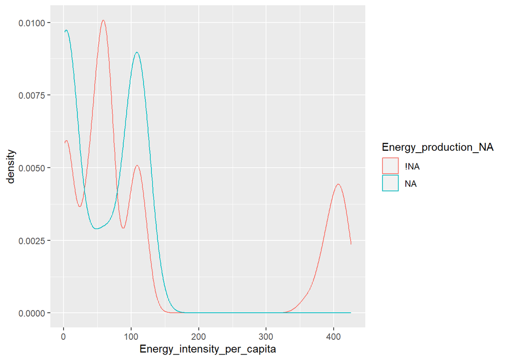

```r
energy%>%
  bind_shadow()%>%
  ggplot(aes(x = Energy_intensity_per_capita, color = Energy_production_NA))+
  geom_density()
```

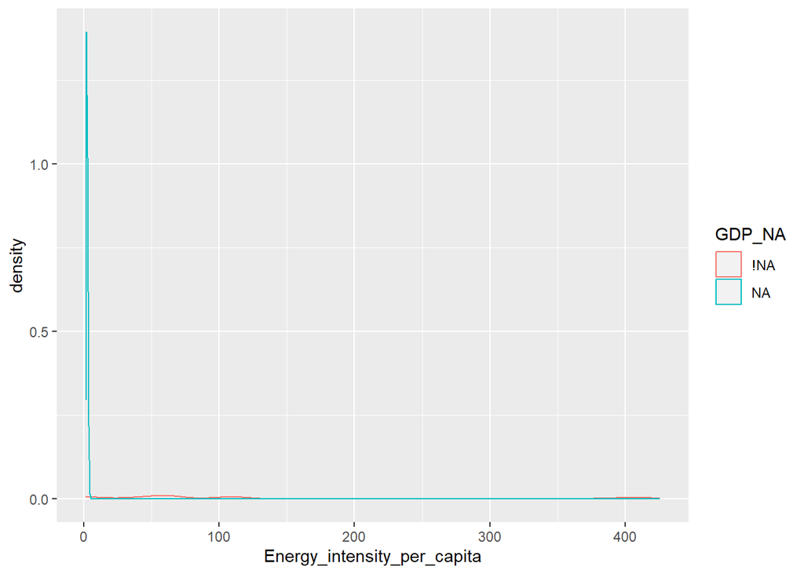

```r
energy%>%
  bind_shadow()%>%
  ggplot(aes(x = Energy_intensity_per_capita, color = GDP_NA))+
  geom_density()
```

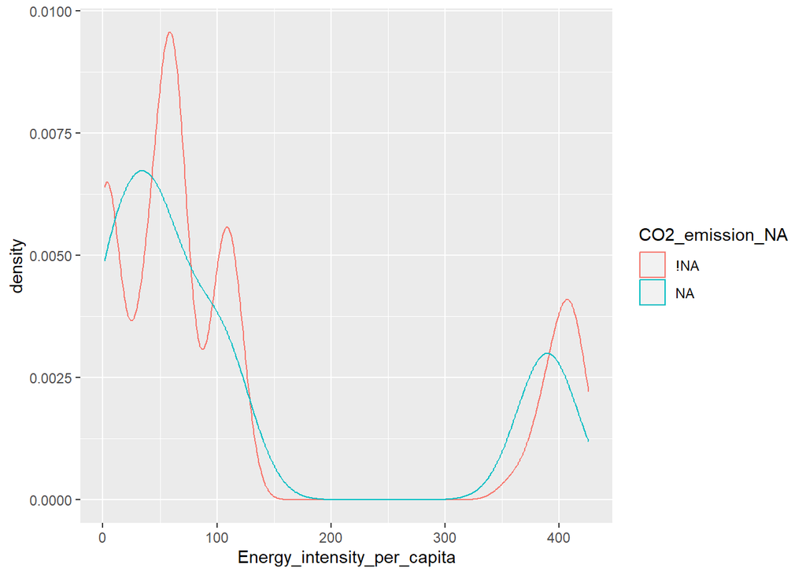

```r
energy%>%
  bind_shadow()%>%
  ggplot(aes(x = Energy_intensity_per_capita, color = CO2_emission_NA))+
  geom_density()
```

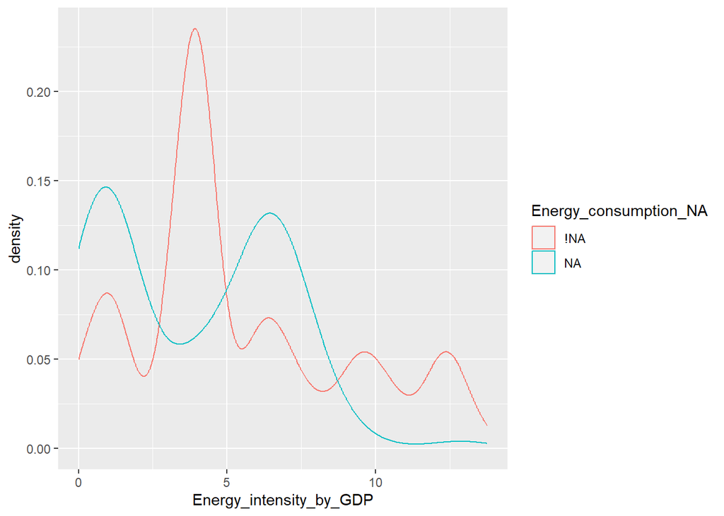

```r
#Variation
  #Energy_consumption
  #Energy_production

energy%>%
  bind_shadow()%>%
  ggplot(aes(x = Energy_intensity_by_GDP, color = Energy_consumption_NA))+
  geom_density()
```

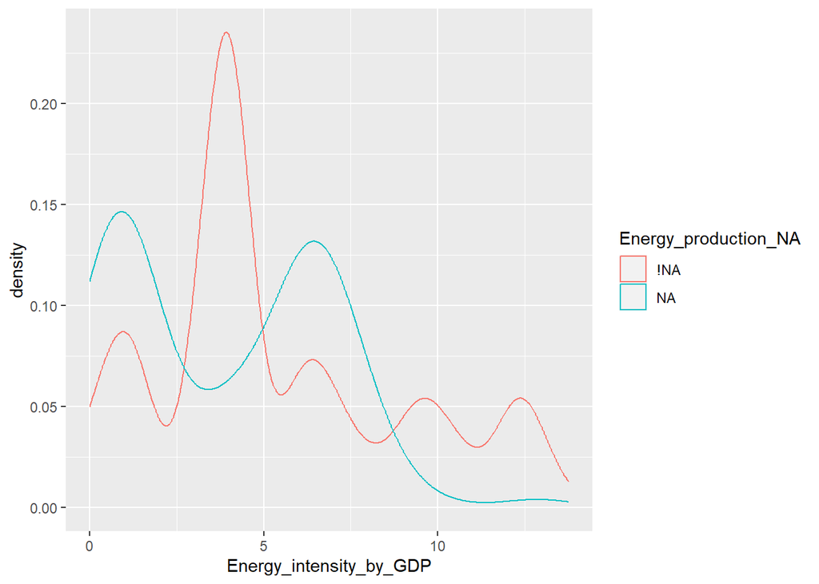

```r
energy%>%
  bind_shadow()%>%
  ggplot(aes(x = Energy_intensity_by_GDP, color = Energy_production_NA))+
  geom_density()
```

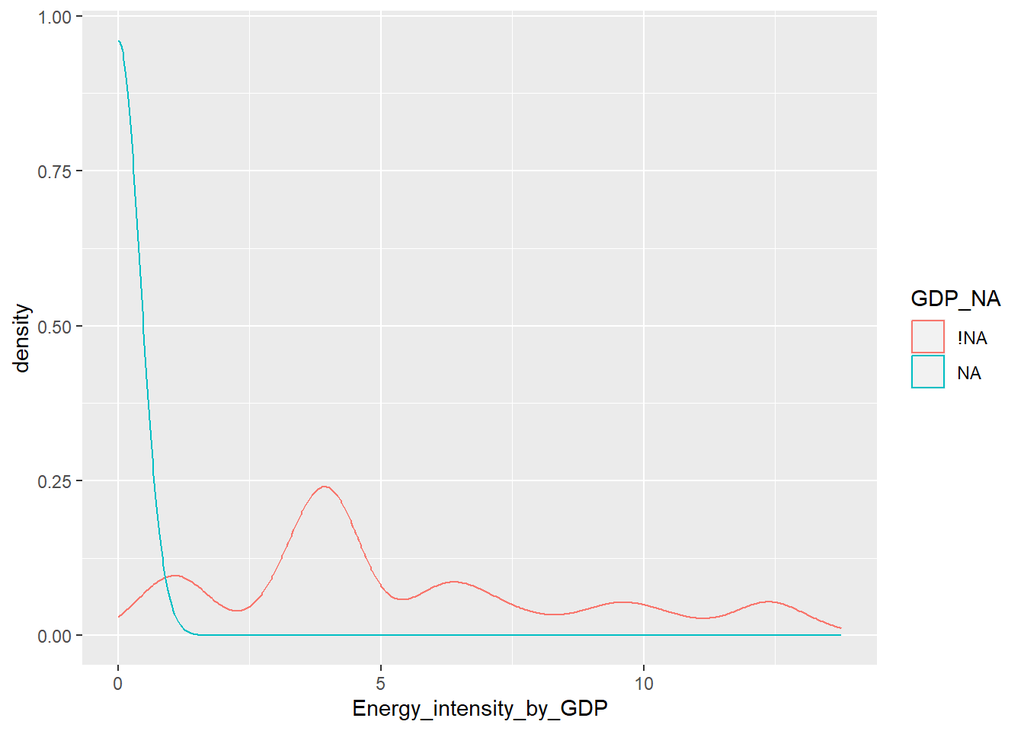

```r
energy%>%
  bind_shadow()%>%
  ggplot(aes(x = Energy_intensity_by_GDP, color = GDP_NA))+
  geom_density()
```

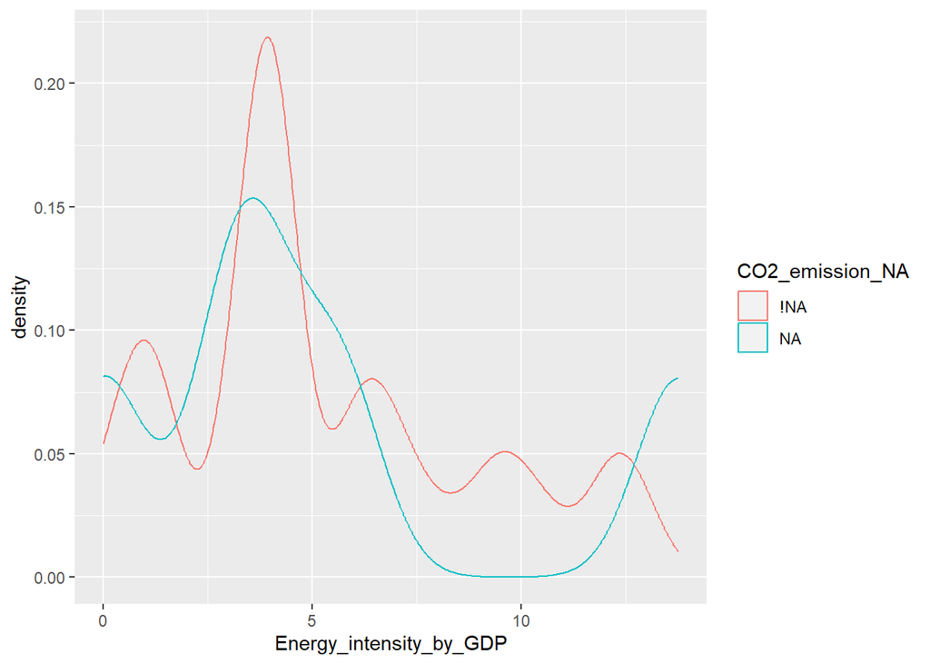

```r
energy%>%
  bind_shadow()%>%
  ggplot(aes(x = Energy_intensity_by_GDP, color = CO2_emission_NA))+
  geom_density()
```

```r
#Variation
  #Energy_consumption
  #Energy_production
  #GDP
```

In energy:

- Energy intensity per capita
  - Energy Consumption
  - Energy Production
- Energy intensity by GDP
  - Energy Consumption
  - Energy Production
  - GDP

### **Consumption**

```r
#Missing
  #oil_consumption
  #other_renewable_consumption
  #renewables_consumption
  #wind_consumption
  #solar_consumption

#Possible variation
  #There is no
```

In consumption, we saw that there is any relation between variables with no missing data and variables with missing, so we didn’t create the charts.

This is useful to know so in the next steps we can create the imputation models with linear regression with the variables related.

### Imputation

After the analysis of missing data in databases, we had to apply some imputation methods in order to clean them and have more precise results. We made the following methods:

- Below the range
- With the mean
- With linear regression
- With the median
- With 0s

This last method was used because we can suppose that if some data is not registered is because in that country or in that year there was not the energy type we are studying, so it will affect our final results to put some “random” numbers in those cases.

For each imputation model, we created a new database, so it doesn’t affect the original one.

### **Energy**

First, we create them for Energy.

**Below the range**

In the “Below the range” method, first, we looked for the range of each variable with missing data to understand in which values the model will apply the data. Then we create the new dataset with the applied model.

```r
#Look for the range of each variable
renergycon<-range(energy$Energy_consumption)
renergyprod<-range(energy$Energy_production)
rgdp<-range(energy$GDP)
rco2<-range(energy$CO2_emission)

br_energy <- energy %>%
  bind_shadow(only_miss = TRUE) %>%
  add_label_shadow() %>%
  impute_below_all()
```

**With the mean**

With the mean, we only used the function *impute_mean_all* and keep it in a new object.

```r
mean_energy<- energy%>%
  bind_shadow(only_miss = TRUE)%>%
  add_label_shadow()%>%
  impute_mean_all()
```

**With linear regresion**

In the “Linear regression” model, we used the variables that we found in the analysis of variables in the Missing Data section and created the new database.

```r
lm_energy<-energy%>%
  bind_shadow(only_miss = TRUE)%>%
  add_label_shadow()%>%
  impute_lm(Energy_consumption ~ Energy_intensity_per_capita + Energy_intensity_by_GDP) %>%
  impute_lm(Energy_production ~ Energy_intensity_per_capita + Energy_intensity_by_GDP) %>%
  impute_lm(GDP ~ Energy_intensity_per_capita + Energy_intensity_by_GDP) %>%
  impute_lm(CO2_emission ~ Energy_intensity_per_capita + Energy_intensity_by_GDP)
```

**With the median**

In the same case as in the “Mean model”, we used the function *impute_median_all* to apply the model.

```r
median_energy<- energy%>%
  bind_shadow(only_miss = TRUE)%>%
  add_label_shadow()%>%
  impute_median_all()
```

**With the mode**

In the model with “Mode”, first we looked for the mode of each variable with missing data but we found that the mode is 0 or an NA, so we couldn’t apply this model. It is also important to mention that we had to create the function *modef* because this function doesn’t exist in the used packages.

```r
modef<-function(x){
  y<-unique(x)
  tab<-tabulate(match(x,y))
  y[tab==max(tab)]
}
modef(energy$Energy_consumption)
```

```
## [1] NA
```

```r
modef(energy$Energy_production)
```

```
## [1] 0
```

```r
modef(energy$GDP)
```

```
## [1] NA
```

```r
modef(energy$CO2_emission)
```

```
## [1] 0
```

```r
#There is no mode or is 0
```

**With 0s**

Finally, with 0s, we used the function *mutate_if*, so we can look for the registries that have NAs and replace them with 0s.

```r
Na_0_en<-energy%>%
  bind_shadow(only_miss = TRUE)%>%
  add_label_shadow()%>%
  mutate_if(is.numeric, ~replace(., is.na(.), 0))
```

### **Consumption**

In consumption, we applied almost the same methods as we can see in the following lines:

**Below the range**

First, we applied the “Below the range” model.

```r
br_consumption<-consumption%>%
  bind_shadow(only_miss = TRUE)%>%
  add_label_shadow()%>%
  impute_below_all()
```

**With the mean**

Then we did the same with the mean.

```r
mean_consumption<-consumption%>%
  bind_shadow(only_miss = TRUE)%>%
  add_label_shadow()%>%
  impute_mean_all()
```

**With the median**

And also, with the median.

```r
median_consumption<-consumption%>%
  bind_shadow(only_miss = TRUE)%>%
  add_label_shadow()%>%
  impute_median_all()
```

**With the mode**

For the mode, we looked for it in each variable but again found there is no mode.

```r
modef(consumption$oil_consumption)
```

```
## [1] NA
```

```r
modef(consumption$other_renewable_consumption)
```

```
## [1] NA
```

```r
modef(consumption$renewables_consumption)
```

```
## [1] NA
```

```r
modef(consumption$wind_consumption)
```

```
## [1] NA
```

```r
modef(consumption$solar_consumption)
```

```
## [1] NA
```

```r
#There is no mode
```

**With 0s**

Finally applied the “0s” method in the same way as with Energy.

```r
Na_0_con<-consumption%>%
  bind_shadow(only_miss = TRUE)%>%
  add_label_shadow()%>%
  mutate_if(is.numeric, ~replace(., is.na(.), 0))
```

In this case, we didn’t use the “Linear regression” method because there weren’t related variables in this database.

We also have to mention that in each of the models we applied the nabularies to know which data is missing. This was made with the functions *bind_shadow* and *add_label_shadow*.

**Evaluation of the methods**

### **Energy**

First, we evaluate the ones in energy.

```r
eva_modelos_energy<-bind_rows(br=br_energy,
                              mean=mean_energy,
                              lm=lm_energy,
                              median=median_energy,
                              Na0=Na_0_en,
                              .id="imp_model")

model_summary_energy<-eva_modelos_energy%>%
  group_by(imp_model)%>%
  nest()%>%
  mutate(mod=map(data,          ~lm(Energy_intensity_by_GDP~Energy_consumption + Energy_production + GDP + CO2_emission,
                     data=.)),
         res=map(mod, residuals),
         pred=map(mod, predict),
         tidy=map(mod, broom::tidy))

model_summary_energy
```

```
## # A tibble: 5 × 6
## # Groups:   imp_model [5]
##   imp_model data                  mod    res           pred          tidy
##   <chr>     <list>                <list> <list>        <list>        <list>
## 1 br        <tibble [1,200 × 16]> <lm>   <dbl [1,200]> <dbl [1,200]> <tibble>
## 2 mean      <tibble [1,200 × 16]> <lm>   <dbl [1,200]> <dbl [1,200]> <tibble>
## 3 lm        <tibble [1,200 × 16]> <lm>   <dbl [1,200]> <dbl [1,200]> <tibble>
## 4 median    <tibble [1,200 × 16]> <lm>   <dbl [1,200]> <dbl [1,200]> <tibble>
## 5 Na0       <tibble [1,200 × 16]> <lm>   <dbl [1,200]> <dbl [1,200]> <tibble>
```

```r
eval_summary_energy<-model_summary_energy%>%
  select(imp_model, tidy)%>%
  unnest()
eval_summary_energy
```

```
## # A tibble: 25 × 6
## # Groups:   imp_model [5]
##    imp_model term                 estimate std.error statistic   p.value
##    <chr>     <chr>                   <dbl>     <dbl>     <dbl>     <dbl>
##  1 br        (Intercept)         4.40       0.152       28.9   1.27e-139
##  2 br        Energy_consumption -0.0146     0.105       -0.139 8.90e-  1
##  3 br        Energy_production   0.537      0.0652       8.24  4.56e- 16
##  4 br        GDP                 0.000195   0.000125     1.56  1.18e-  1
##  5 br        CO2_emission       -0.00684    0.00162     -4.22  2.60e-  5
##  6 mean      (Intercept)         4.37       0.172       25.4   1.91e-114
##  7 mean      Energy_consumption -0.0371     0.104       -0.356 7.22e-  1
##  8 mean      Energy_production   0.490      0.0684       7.16  1.39e- 12
##  9 mean      GDP                -0.0000476  0.000132    -0.360 7.19e-  1
## 10 mean      CO2_emission       -0.00379    0.00167     -2.27  2.33e-  2
## # … with 15 more rows
```

```r
error_energy<-eval_summary_energy%>%
  summarize(mean=mean(std.error))%>%
  arrange(mean)
```

What we did was to, first, group all the methods, then calculate the linear regression, and finally do the valuation.

### **Consumption**

In consumption, we did exactly the same as can be seen in the following lines:

```r
eva_models_consumption<-bind_rows(br=br_consumption,
                              mean=mean_consumption,
                              Na_0 = Na_0_con,
                              .id="imp_model")

model_summary_consumption<-eva_models_consumption%>%
  group_by(imp_model)%>%
  nest()%>%
  mutate(mod=map(data,          ~lm(renewables_consumption~oil_consumption + other_renewable_consumption + wind_consumption + solar_consumption,
                     data=.)),
         res=map(mod, residuals),
         pred=map(mod, predict),
         tidy=map(mod, broom::tidy))
model_summary_consumption
```

```
## # A tibble: 3 × 6
## # Groups:   imp_model [3]
##   imp_model data                mod    res         pred        tidy
##   <chr>     <list>              <list> <list>      <list>      <list>
## 1 br        <tibble [523 × 14]> <lm>   <dbl [523]> <dbl [523]> <tibble [5 × 5]>
## 2 mean      <tibble [523 × 14]> <lm>   <dbl [523]> <dbl [523]> <tibble [5 × 5]>
## 3 Na_0      <tibble [523 × 14]> <lm>   <dbl [523]> <dbl [523]> <tibble [5 × 5]>
```

```r
eval_summary_consumption<-model_summary_consumption%>%
  select(imp_model,
         tidy)%>%
  unnest()
eval_summary_consumption
```

```
## # A tibble: 15 × 6
## # Groups:   imp_model [3]
##    imp_model term                        estimate std.error statistic  p.value
##    <chr>     <chr>                          <dbl>     <dbl>     <dbl>    <dbl>
##  1 br        (Intercept)                  -63.3     15.6       -4.07  5.47e- 5
##  2 br        oil_consumption                0.575    0.0325    17.7   3.05e-55
##  3 br        other_renewable_consumption    5.01     0.794      6.32  5.81e-10
##  4 br        wind_consumption               2.03     1.05       1.93  5.41e- 2
##  5 br        solar_consumption             -8.81     5.44      -1.62  1.06e- 1
##  6 mean      (Intercept)                  -64.1     24.5       -2.61  9.24e- 3
##  7 mean      oil_consumption                0.576    0.0395    14.6   1.29e-40
##  8 mean      other_renewable_consumption    5.01     0.796      6.29  6.59e-10
##  9 mean      wind_consumption               2.02     1.06       1.90  5.74e- 2
## 10 mean      solar_consumption             -8.78     5.89      -1.49  1.37e- 1
## 11 Na_0      (Intercept)                   -7.74     9.08      -0.852 3.94e- 1
## 12 Na_0      oil_consumption                0.502    0.0235    21.4   4.96e-73
## 13 Na_0      other_renewable_consumption    5.51     0.770      7.15  2.94e-12
## 14 Na_0      wind_consumption               1.98     1.07       1.86  6.41e- 2
## 15 Na_0      solar_consumption             -8.15     5.92      -1.38  1.69e- 1
```

```r
error_consumption<-eval_summary_consumption%>%
  summarize(mean=mean(std.error))%>%
  arrange(mean)
```

**Final imputation**

In this section, we applied the final imputation to the real databases.

```r
energy<-energy%>%
  bind_shadow(only_miss = TRUE)%>%
  add_label_shadow()%>%
  impute_below_all()

consumption<-consumption%>%
  bind_shadow(only_miss = TRUE)%>%
  add_label_shadow()%>%
  mutate_if(is.numeric, ~replace(., is.na(.), 0))
```

### Outliers

We also have to check the outliers for each variable in each database.

### **Energy**

Then, to know which are those outliers we used a filter to look for all of them that are above or below those ranges that we already calculated.

Finally, with an *ifelse* function, we changed all those outliers to the same ones that we calculated at the beginning (the lowers and uppers)

```r
#Mean
#sd
#sd*3 +mean
#every data above those must be changed

mean_en_con<-mean(energy$Energy_consumption)
sd_en_con<-sd(energy$Energy_consumption)

mean_en_prod<-mean(energy$Energy_production)
sd_en_prod<-sd(energy$Energy_production)

mean_enGDP<-mean(energy$GDP)
sd_enGDP<-sd(energy$GDP)

mean_enCO2<-mean(energy$CO2_emission)
sd_enCO2<-sd(energy$CO2_emission)

mean_en_int<-mean(energy$Energy_intensity_per_capita)
sd_en_int<-sd(energy$Energy_intensity_per_capita)

mean_en_intGDP<-mean(energy$Energy_intensity_by_GDP)
sd_en_intGDP<-sd(energy$Energy_intensity_by_GDP)

mean_enPop<-mean(energy$Population)
sd_enPop<-sd(energy$Population)


en_con_upper<-mean_en_con+(3*sd_en_con)
en_con_lower<-mean_en_con-(3*sd_en_con)

en_prod_upper<-mean_en_prod+(3*sd_en_prod)
en_prod_lower<-mean_en_prod-(3*sd_en_prod)

enGDP_upper<-mean_enGDP+(3*sd_enGDP)
enGDP_lower<-mean_enGDP-(3*sd_enGDP)

enCO2_upper<-mean_enCO2+(3*sd_enCO2)
enCO2_lower<-mean_enCO2-(3*sd_enCO2)

en_int_upper<-mean_en_int+(3*sd_en_int)
en_int_lower<-mean_en_int-(3*sd_en_int)

en_intGDP_upper<-mean_en_intGDP+(3*sd_en_intGDP)
en_intGDP_lower<-mean_en_intGDP-(3*sd_en_intGDP)

enPop_upper<-mean_enPop+(3*sd_enPop)
enPop_lower<-mean_enPop-(3*sd_enPop)


filter_outliers_energy<-energy%>%
  filter(Energy_consumption < en_con_lower | Energy_consumption > en_con_upper | Energy_production < en_prod_lower | Energy_production > en_con_upper | GDP < enGDP_lower | GDP > enGDP_upper | CO2_emission < enCO2_lower | CO2_emission > enCO2_upper | Energy_intensity_per_capita < en_int_lower | Energy_intensity_per_capita > en_int_upper | Energy_intensity_by_GDP < en_intGDP_lower | Energy_intensity_by_GDP > en_intGDP_upper | Population < enPop_lower | Population > enPop_upper)


energy$Energy_consumption<-ifelse(energy$Energy_consumption < en_con_lower, en_con_lower, energy$Energy_consumption)
energy$Energy_consumption<-ifelse(energy$Energy_consumption > en_con_upper, en_con_upper, energy$Energy_consumption)

energy$Energy_production<-ifelse(energy$Energy_production < en_prod_lower, en_prod_lower, energy$Energy_production)
energy$Energy_production<-ifelse(energy$Energy_production > en_prod_upper, en_prod_upper, energy$Energy_production)

energy$GDP<-ifelse(energy$GDP < enGDP_lower, enGDP_lower, energy$GDP)
energy$GDP<-ifelse(energy$GDP > enGDP_upper, enGDP_upper, energy$GDP)

energy$CO2_emission<-ifelse(energy$CO2_emission < enCO2_lower, enCO2_lower, energy$CO2_emission)
energy$CO2_emission<-ifelse(energy$CO2_emission > enCO2_upper, enCO2_upper, energy$CO2_emission)

energy$Energy_intensity_per_capita<-ifelse(energy$Energy_intensity_per_capita < en_int_lower, en_int_lower, energy$Energy_intensity_per_capita)
energy$Energy_intensity_per_capita<-ifelse(energy$Energy_intensity_per_capita > en_int_lower, en_int_lower, energy$Energy_intensity_per_capita)

energy$Energy_intensity_by_GDP<-ifelse(energy$Energy_intensity_by_GDP < en_intGDP_lower, en_intGDP_lower, energy$Energy_intensity_by_GDP)
energy$Energy_intensity_by_GDP<-ifelse(energy$Energy_intensity_by_GDP > en_intGDP_upper, en_intGDP_upper, energy$Energy_intensity_by_GDP)

energy$Population<-ifelse(energy$Population < enPop_lower, enPop_lower, energy$Population)
energy$Population<-ifelse(energy$Population > enPop_upper, enPop_upper, energy$Population)

energy [ energy < 0 ] <- 0
```

### **Consumption**

We did the same process in consumption to fix the outliers.

```r
#oil_consumption
#other_renewable_consumption
#renewables_consumption
#wind_consumption
#solar_consumption

mean_oil_con<-mean(consumption$oil_consumption)
sd_oil_con<-sd(consumption$oil_consumption)

mean_oth_con<-mean(consumption$other_renewable_consumption)
sd_oth_con<-sd(consumption$other_renewable_consumption)

mean_ren_con<-mean(consumption$renewables_consumption)
sd_ren_con<-mean(consumption$renewables_consumption)

mean_win_con<-mean(consumption$wind_consumption)
sd_win_con<-sd(consumption$wind_consumption)

mean_sol_con<-mean(consumption$solar_consumption)
sd_sol_con<-sd(consumption$solar_consumption)


co_oil_upper<-mean_oil_con+(3*sd_oil_con)

co_oth_upper<-mean_oth_con+(3*sd_oth_con)

co_ren_upper<-mean_ren_con+(3*sd_ren_con)

co_win_upper<-mean_win_con+(3*sd_win_con)

co_sol_upper<-mean_sol_con+(3*sd_sol_con)


consumption$oil_consumption<-ifelse(consumption$oil_consumption > co_oil_upper, co_oil_upper, consumption$oil_consumption)

consumption$other_renewable_consumption<-ifelse(consumption$other_renewable_consumption > co_oth_upper, co_oth_upper, consumption$other_renewable_consumption)

consumption$renewables_consumption<-ifelse(consumption$renewables_consumption > co_ren_upper, co_ren_upper, consumption$renewables_consumption)

consumption$wind_consumption<-ifelse(consumption$wind_consumption > co_win_upper, co_win_upper, consumption$wind_consumption)

consumption$solar_consumption<-ifelse(consumption$solar_consumption > co_sol_upper, co_sol_upper, consumption$solar_consumption)
```

In statistics, we didn’t apply this because, if we give a look at the database, we see that there is only one column with numbers which means the number of units operated in each country and for each energy type, however, these units are not the same, some are calculated in terajoules, others in metric tons thousands, etc. we can’t apply a method for outliers because not all registries are calculated in the same way.

# **Analysis**

Finally, and after cleaning our databases, we will make a first analysis of the variables and their relations.

### **Energy Consumption**

#### **Mean and Standard Deviation**

Energy consumption is from our database Energy, first, we want to know the total mean and standard deviation of consumption, no matter the energy type or country.

```r
mean(energy$Energy_consumption)
```

```
## [1] 1.88
```

```r
sd(energy$Energy_consumption)
```

```
## [1] 2.65
```

**For each country**

However, it is also important to look for them by country.

```r
group_by(energy, Country)%>%
  filter(Energy_type!="all_energy_types")%>%
  summarize(mean=mean(Energy_consumption))%>%
  arrange(desc(mean))
```

```
## # A tibble: 5 × 2
##   Country      mean
##   <fct>       <dbl>
## 1 Canada    2.47
## 2 Brazil    1.64
## 3 Mexico    1.24
## 4 Venezuela 0.510
## 5 Haiti     0.00524
```

```r
group_by(energy, Country)%>%
  filter(Energy_type!="all_energy_types")%>%
  summarize(sd=sd(Energy_consumption))%>%
  arrange(desc(sd))
```

```
## # A tibble: 5 × 2
##   Country       sd
##   <fct>      <dbl>
## 1 Brazil    1.79
## 2 Mexico    1.42
## 3 Canada    1.40
## 4 Venezuela 0.483
## 5 Haiti     0.0107
```

**By country and Energy type**

```r
group_by(energy, Country, Energy_type)%>%
  filter(Energy_type!="all_energy_types")%>%
  summarize(mean=mean(Energy_consumption))%>%
  arrange(desc(mean))
```

```
## # A tibble: 25 × 3
## # Groups:   Country [5]
##    Country   Energy_type                mean
##    <fct>     <fct>                     <dbl>
##  1 Canada    petroleum_n_other_liquids 4.06
##  2 Brazil    petroleum_n_other_liquids 3.95
##  3 Mexico    petroleum_n_other_liquids 3.71
##  4 Canada    renewables_n_other        3.37
##  5 Brazil    renewables_n_other        3.15
##  6 Canada    natural_gas               3.07
##  7 Mexico    natural_gas               1.73
##  8 Venezuela petroleum_n_other_liquids 1.06
##  9 Canada    coal                      0.964
## 10 Venezuela natural_gas               0.947
## # … with 15 more rows
```

```r
group_by(energy, Country, Energy_type)%>%
  filter(Energy_type!="all_energy_types")%>%
  summarize(sd=sd(Energy_consumption))%>%
  arrange(desc(sd))
```

```
## # A tibble: 25 × 3
## # Groups:   Country [5]
##    Country   Energy_type                  sd
##    <fct>     <fct>                     <dbl>
##  1 Brazil    petroleum_n_other_liquids 1.42
##  2 Brazil    renewables_n_other        1.04
##  3 Canada    natural_gas               0.788
##  4 Canada    petroleum_n_other_liquids 0.728
##  5 Mexico    natural_gas               0.722
##  6 Brazil    natural_gas               0.470
##  7 Mexico    petroleum_n_other_liquids 0.454
##  8 Canada    renewables_n_other        0.358
##  9 Venezuela petroleum_n_other_liquids 0.278
## 10 Venezuela renewables_n_other        0.207
## # … with 15 more rows
```

Divided by energy type and country, we found that the one with the highest mean is Canada with petroleum (4.05), then Brazil with petroleum (3.9), and Mexico with petroleum again (3.7). The lowest ones are Haiti and Venezuela with nuclear (it seems they don’t have this energy type) and Haiti with natural gas, coal, and renewables, and others.

#### **Distribution**

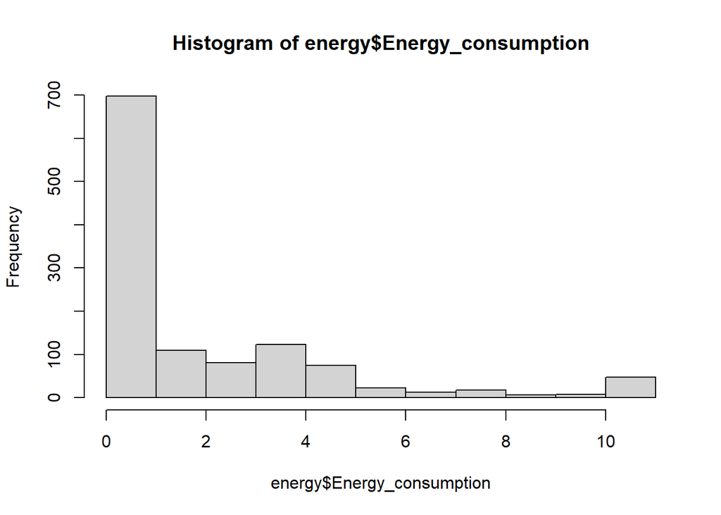

```r
hist(energy$Energy_consumption)
```

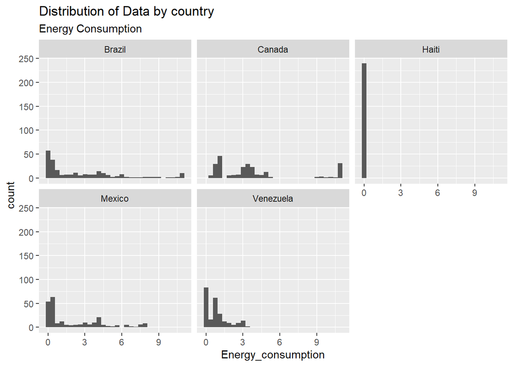

```r
ggplot(energy, aes(x=Energy_consumption))+
  geom_histogram()+
  facet_wrap(~Country)+
  labs(title="Distribution of Data by country",
       subtitle="Energy Consumption")
```

It is also important to understand the distribution of this variable. In the first graph, we see that most of the data is in the first places and continuously is going down to the last places. Divided by country, the one with the most normal distribution might be Canada, the other ones also have most of the data in the first places and less in the last ones and Haiti has all its data grouped in the same range.

#### **Use of energy in the last year registered for each country**

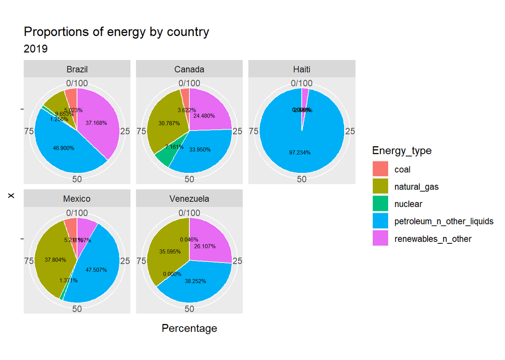

```r
energy_consumption_2019<-energy%>%
  filter(Year==2019, Energy_type!="all_energy_types")%>%
  group_by(Country)%>%
  mutate(Total=sum(Energy_consumption), Percentage=Energy_consumption/Total*100)

ggplot(data=energy_consumption_2019,aes(x="",y=Percentage, fill=Energy_type))+
  geom_bar(stat = "identity",color="white")+
    geom_text(aes(label=percent(Percentage/100)),
              position=position_stack(vjust=0.5),color="black",size=2)+
  coord_polar(theta="y")+
  facet_wrap(~Country)+
  labs(title="Proportions of energy by country",
      subtitle="2019")
```

We also want to know how much of each energy was used in the last year registered (2019 in this case) by country, so we did a pie graph to understand this. In almost all countries the one that is used the most is petroleum. Canada, Mexico, and Venezuela consume big quantities as well of natural gas, Brazil, Canada, and Venezuela are the ones with the most use of renewable energy and Haiti only uses petroleum and a little renewable.

#### **Growth**

We looked for the growth of consumption by energy type in each country and did some graphs to visualize it.

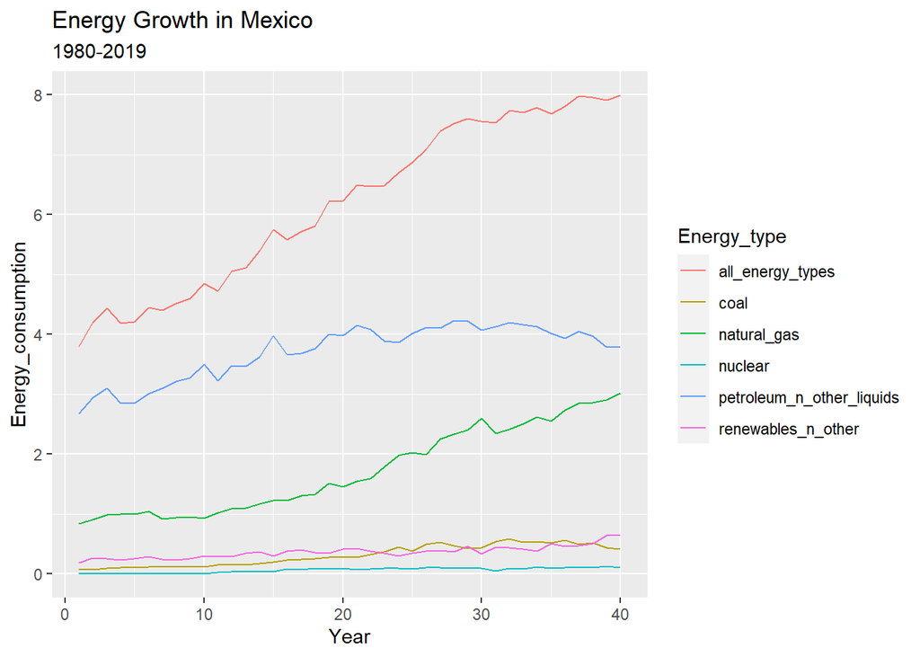

```r
energy_consumption_mexico<-energy%>%
  filter( Country=="Mexico")%>%
  mutate(Year=as.numeric(Year))%>%
  group_by(Energy_type)

ggplot(data=energy_consumption_mexico, mapping=aes(x=Year, y=Energy_consumption, color=Energy_type))+
  geom_line()+
  labs(title="Energy Growth in Mexico",
       subtitle="1980-2019")
```

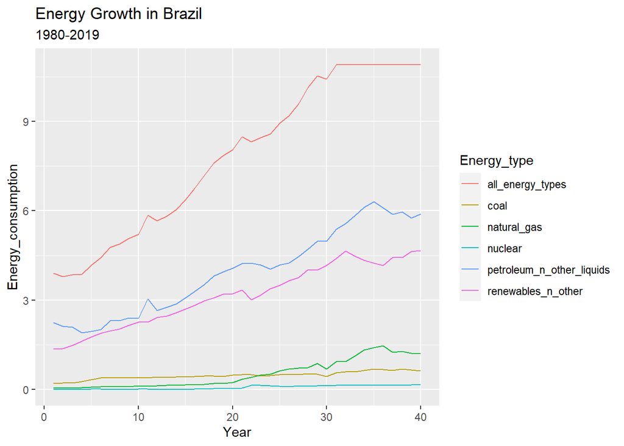

```r
energy_consumption_brazil<-energy%>%
  filter( Country=="Brazil")%>%
  mutate(Year=as.numeric(Year))%>%
  group_by(Energy_type)

ggplot(data=energy_consumption_brazil, mapping=aes(x=Year, y=Energy_consumption, color=Energy_type))+
  geom_line()+
  labs(title="Energy Growth in Brazil",
       subtitle="1980-2019")
```

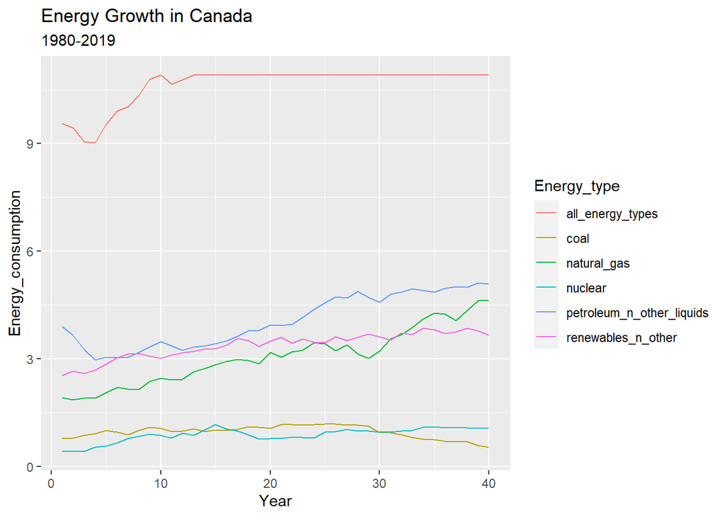

```r
energy_consumption_canada<-energy%>%
  filter( Country=="Canada")%>%
  mutate(Year=as.numeric(Year))%>%
  group_by(Energy_type)

ggplot(data=energy_consumption_canada, mapping=aes(x=Year, y=Energy_consumption, color=Energy_type))+
  geom_line()+
  labs(title="Energy Growth in Canada",
       subtitle="1980-2019")
```

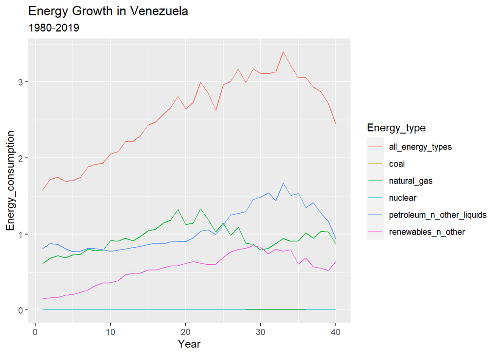

```r
energy_consumption_venezuela<-energy%>%
  filter( Country=="Venezuela")%>%
  mutate(Year=as.numeric(Year))%>%
  group_by(Energy_type)

ggplot(data=energy_consumption_venezuela, mapping=aes(x=Year, y=Energy_consumption, color=Energy_type))+
  geom_line()+
  labs(title="Energy Growth in Venezuela",
       subtitle="1980-2019")
```

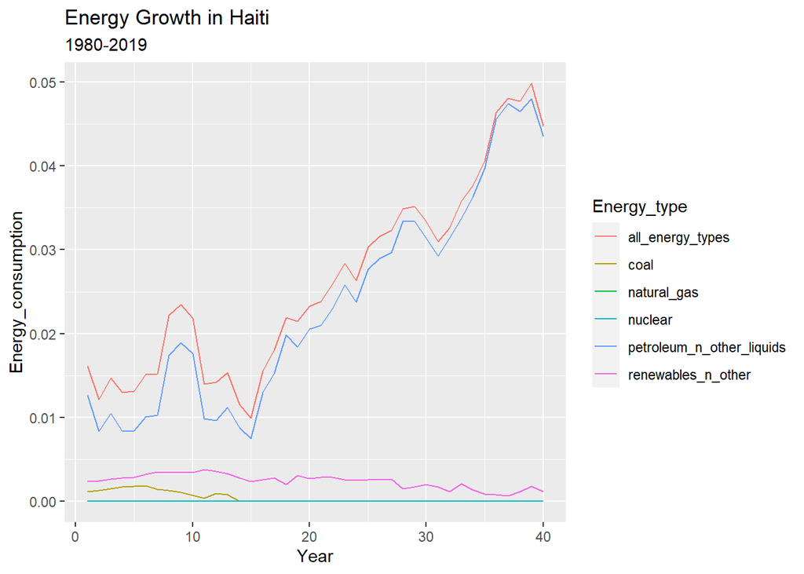

```r
energy_consumption_haiti<-energy%>%
  filter( Country=="Haiti")%>%
  mutate(Year=as.numeric(Year))%>%
  group_by(Energy_type)

ggplot(data=energy_consumption_haiti, mapping=aes(x=Year, y=Energy_consumption, color=Energy_type))+
  geom_line()+
  labs(title="Energy Growth in Haiti",
       subtitle="1980-2019")
```

In Mexico, we see that the highest in consumption is petroleum (with a decrease in some moments) but that natural gas had a growth in the last years. Nuclear, renewables, and coal are the ones less used and with no growth.

In Brazil, the ones with the most growth are petroleum and renewables, in Canada petroleum and Natural Gas, in Venezuela petroleum and natural gas had a growth but then decrease their consumption and in Haiti the one with the most growth is petroleum.

### **Energy production**

We did the same analysis for Energy Production in energy.

#### **Mean and Standard Deviation**

```r
mean(energy$Energy_production)
```

```
## [1] 2.48
```

```r
sd(energy$Energy_production)
```

```
## [1] 3.48
```

First, we took the mean and standard deviation of all energies and countries which are 2.48 and 3.48 respectively.

**For each country**

```r
group_by(energy, Country)%>%
  filter(Energy_type!= "all_energy_types")%>%
  summarize(mean=mean(Energy_production))%>%
  arrange(desc(mean))
```

```
## # A tibble: 5 × 2
##   Country       mean
##   <fct>        <dbl>
## 1 Canada    3.32
## 2 Mexico    1.66
## 3 Venezuela 1.40
## 4 Brazil    1.35
## 5 Haiti     0.000481
```

```r
group_by(energy, Country)%>%
  filter(Energy_type!= "all_energy_types")%>%
  summarize(sd=sd(Energy_production))%>%
  arrange(desc(sd))
```

```
## # A tibble: 5 × 2
##   Country        sd
##   <fct>       <dbl>
## 1 Mexico    2.44
## 2 Canada    2.26
## 3 Venezuela 2.12
## 4 Brazil    1.74
## 5 Haiti     0.00103
```

Then we calculated the mean and standard deviation by country, Canada with the highest production (3.32) and Haiti with the lowest (0.0004).

**By country and Energy type**

```r
group_by(energy, Country, Energy_type)%>%
  filter(Energy_type!= "all_energy_types")%>%
  summarize(mean=mean(Energy_production))%>%
  arrange(desc(mean))
```

```
## # A tibble: 25 × 3
## # Groups:   Country [5]
##    Country   Energy_type                mean
##    <fct>     <fct>                     <dbl>
##  1 Mexico    petroleum_n_other_liquids 6.37
##  2 Canada    petroleum_n_other_liquids 5.69
##  3 Venezuela petroleum_n_other_liquids 5.43
##  4 Canada    natural_gas               5.19
##  5 Canada    renewables_n_other        3.49
##  6 Brazil    renewables_n_other        3.41
##  7 Brazil    petroleum_n_other_liquids 2.85
##  8 Canada    coal                      1.36
##  9 Mexico    natural_gas               1.31
## 10 Venezuela natural_gas               0.937
## # … with 15 more rows
```

```r
group_by(energy, Country, Energy_type)%>%
  filter(Energy_type!= "all_energy_types")%>%
  summarize(sd=sd(Energy_production))%>%
  arrange(desc(sd))
```

```
## # A tibble: 25 × 3
## # Groups:   Country [5]
##    Country   Energy_type                  sd
##    <fct>     <fct>                     <dbl>
##  1 Canada    petroleum_n_other_liquids 2.09
##  2 Brazil    petroleum_n_other_liquids 1.74
##  3 Canada    natural_gas               1.45
##  4 Brazil    renewables_n_other        1.18
##  5 Venezuela petroleum_n_other_liquids 1.15
##  6 Mexico    petroleum_n_other_liquids 0.988
##  7 Canada    renewables_n_other        0.391
##  8 Mexico    natural_gas               0.344
##  9 Brazil    natural_gas               0.259
## 10 Venezuela renewables_n_other        0.209
## # … with 15 more rows
```

Finally, we did the same calculations by energy and country. Mexico is the biggest producer of petroleum with 6.37, then Canada (5.68) and Venezuela (5.43). We see that Haiti doesn’t produce coal, natural gas, nuclear energy, and petroleum while Venezuela doesn’t produce nuclear energy.

#### **Distribution**

In the distribution analysis of this variable, we see that most of the cases are valued in the first positions. Divided by countries, Brazil, Mexico, and Venezuela have most of their data in the first positions, Haiti all of it, and Canada’s data is registered in different positions.

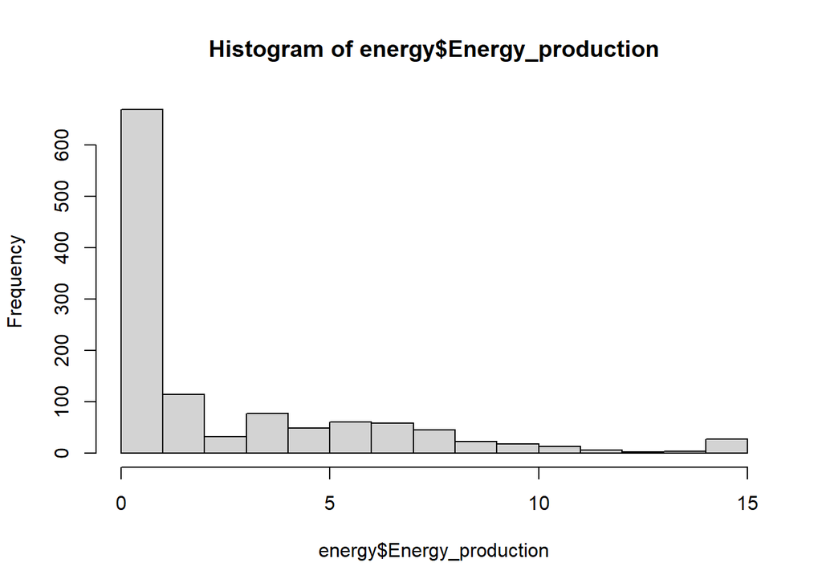

```r
hist(energy$Energy_production)
```

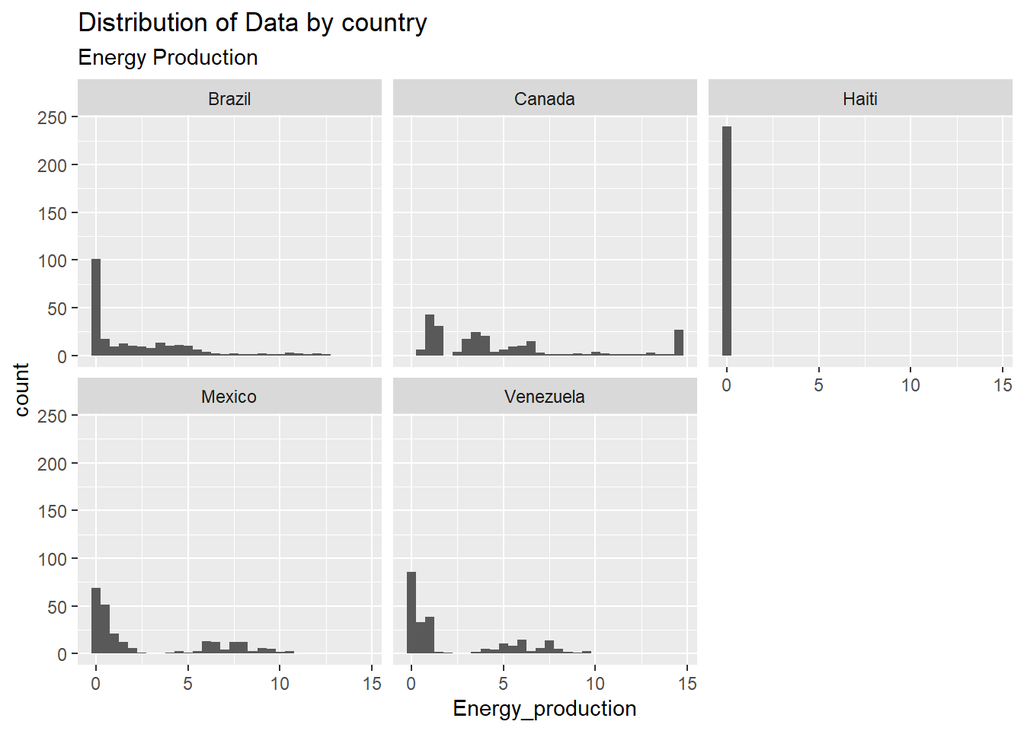

```r
ggplot(energy, aes(x=Energy_production))+
  geom_histogram()+
  facet_wrap(~Country)+
  labs(title="Distribution of Data by country",
       subtitle="Energy Production")
```